# Data Exploration & Visualization (City service requests made in Vancouver, British Columbia from 2022 to the present.)

```r
library(tidyverse)
library(dplyr)
vancouver_df <- read.csv('./vancouver_311_requests.csv', sep = ';')
head(vancouver_df)
```

|  | Department | Service.request.type | Status | Closure.reason | Service.request.open.timestamp | Service.request.close.date | Last.modified.timestamp | Address | Local.area | Channel | Latitude | Longitude | geom |
| --- | --- | --- | --- | --- | --- | --- | --- | --- | --- | --- | --- | --- | --- |
| 1 | ENG - Parking Enforcement and Operations | Abandoned or Uninsured Vehicle Case | Close | Insufficient info | 2023-10-24T16:38:00-04:00 | 2023-10-24 | 2023-10-24T18:58:39-04:00 |  |  | Mobile App | NA | NA |  |
| 2 | FSC - Property Tax | Property Tax Request Case | Close | Alternate Service Required | 2023-10-24T16:40:00-04:00 | 2023-10-25 | 2023-10-25T14:05:13-04:00 |  | Fairview | Phone | NA | NA |  |
| 3 | DBL - Services Centre | Building and Development Inquiry Case | Close | Service provided | 2023-10-24T16:42:00-04:00 | 2023-10-27 | 2023-10-27T17:09:55-04:00 |  | Downtown | WEB | NA | NA |  |
| 4 | DBL - Services Centre | Building and Development Inquiry Case | Close | Service provided | 2023-10-24T16:45:00-04:00 | 2023-10-27 | 2023-10-27T15:05:34-04:00 |  | Arbutus Ridge | WEB | NA | NA |  |
| 5 | DBL - Services Centre | Tenant Improvement Program Request Case | Close | Service provided | 2023-10-24T16:48:00-04:00 | 2023-10-27 | 2023-10-27T12:35:20-04:00 |  | Strathcona | WEB | NA | NA |  |
| 6 | ENG - Sanitation Services | Abandoned Recyclables Case | Close | Service provided | 2023-10-24T16:52:00-04:00 | 2023-11-02 | 2023-11-02T15:35:38-04:00 | 3 ALEXANDER ST | Downtown | WEB | 49.28369 | -123.104 | 49.28368575572, -123.10397851188 |

```r
str(vancouver_df)
```

```
## 'data.frame':    842862 obs. of  13 variables:
##  $ Department                    : chr  "ENG - Parking Enforcement and Operations" "FSC - Property Tax" "DBL - Services Centre" "DBL - Services Centre" ...
##  $ Service.request.type          : chr  "Abandoned or Uninsured Vehicle Case" "Property Tax Request Case" "Building and Development Inquiry Case" "Building and Development Inquiry Case" ...
##  $ Status                        : chr  "Close" "Close" "Close" "Close" ...
##  $ Closure.reason                : chr  "Insufficient info" "Alternate Service Required" "Service provided" "Service provided" ...
##  $ Service.request.open.timestamp: chr  "2023-10-24T16:38:00-04:00" "2023-10-24T16:40:00-04:00" "2023-10-24T16:42:00-04:00" "2023-10-24T16:45:00-04:00" ...
##  $ Service.request.close.date    : chr  "2023-10-24" "2023-10-25" "2023-10-27" "2023-10-27" ...
##  $ Last.modified.timestamp       : chr  "2023-10-24T18:58:39-04:00" "2023-10-25T14:05:13-04:00" "2023-10-27T17:09:55-04:00" "2023-10-27T15:05:34-04:00" ...
##  $ Address                       : chr  "" "" "" "" ...
##  $ Local.area                    : chr  "" "Fairview" "Downtown" "Arbutus Ridge" ...
##  $ Channel                       : chr  "Mobile App" "Phone" "WEB" "WEB" ...
##  $ Latitude                      : num  NA NA NA NA NA ...
##  $ Longitude                     : num  NA NA NA NA NA ...
##  $ geom                          : chr  "" "" "" "" ...
```

str() function shows structure of an object. From the result above we can see that, type of our dataset is data.frame which consists of 842862 rows and 13 columns. And also shows the type of each column.

```r
unique(vancouver_df$Local.area)
```

```
##  [1] ""                         "Fairview"
##  [3] "Downtown"                 "Arbutus Ridge"
##  [5] "Strathcona"               "Mount Pleasant"
##  [7] "Shaughnessy"              "West Point Grey"
##  [9] "Kitsilano"                "West End"
## [11] "Sunset"                   "South Cambie"
## [13] "Marpole"                  "Kensington-Cedar Cottage"
## [15] "Grandview-Woodland"       "Oakridge"
## [17] "Hastings-Sunrise"         "Renfrew-Collingwood"
## [19] "Riley Park"               "Victoria-Fraserview"
## [21] "Kerrisdale"               "Killarney"
## [23] "Dunbar-Southlands"
```

```r
length(unique(vancouver_df$Local.area))
```

```
## [1] 23
```

In our dataset 23 unique values of Local.area including empty value.

```r
sunset_df <- filter(vancouver_df, Local.area == 'Sunset')
nrow(sunset_df)
```

```
## [1] 33036
```

Now I have 33036 records from my area Sunset.

```r
str(sunset_df)
```

```
## 'data.frame':    33036 obs. of  13 variables:
##  $ Department                    : chr  "DBL - Services Centre" "DBL - Animal Services" "DBL - Services Centre" "DBL - Property Use Inspections" ...
##  $ Service.request.type          : chr  "Building and Development Inquiry Case" "Animal Concern Case" "Building and Development Inquiry Case" "Private Property Concern Case" ...
##  $ Status                        : chr  "Close" "Close" "Close" "Close" ...
##  $ Closure.reason                : chr  "Service provided" "Further action has been planned" "Service provided" "Assigned to inspector" ...
##  $ Service.request.open.timestamp: chr  "2023-10-24T18:05:19-04:00" "2023-10-24T20:05:27-04:00" "2023-08-13T14:02:01-04:00" "2023-08-13T22:54:01-04:00" ...
##  $ Service.request.close.date    : chr  "2023-10-25" "2023-10-24" "2023-08-16" "2023-08-16" ...
##  $ Last.modified.timestamp       : chr  "2023-10-25T14:20:17-04:00" "2023-10-24T20:33:26-04:00" "2023-08-16T13:46:59-04:00" "2023-08-16T15:01:47-04:00" ...
##  $ Address                       : chr  "" "" "" "" ...
##  $ Local.area                    : chr  "Sunset" "Sunset" "Sunset" "Sunset" ...
##  $ Channel                       : chr  "WEB" "Phone" "WEB" "WEB" ...
##  $ Latitude                      : num  NA NA NA NA NA ...
##  $ Longitude                     : num  NA NA NA NA NA ...
##  $ geom                          : chr  "" "" "" "" ...
```

The following columns have date-related information: Service.request.open.timestamp, Service.request.close.date, Last.modified.timestamp. Now R see them as character not date.

```r
sunset_df$Service.request.open.timestamp <- as.Date(sunset_df$Service.request.open.timestamp)
sunset_df$Service.request.close.date <- as.Date(sunset_df$Service.request.close.date)
sunset_df$Last.modified.timestamp <- as.Date(sunset_df$Last.modified.timestamp)

str(sunset_df)
```

```
## 'data.frame':    33036 obs. of  13 variables:
##  $ Department                    : chr  "DBL - Services Centre" "DBL - Animal Services" "DBL - Services Centre" "DBL - Property Use Inspections" ...
##  $ Service.request.type          : chr  "Building and Development Inquiry Case" "Animal Concern Case" "Building and Development Inquiry Case" "Private Property Concern Case" ...
##  $ Status                        : chr  "Close" "Close" "Close" "Close" ...
##  $ Closure.reason                : chr  "Service provided" "Further action has been planned" "Service provided" "Assigned to inspector" ...
##  $ Service.request.open.timestamp: Date, format: "2023-10-24" "2023-10-24" ...
##  $ Service.request.close.date    : Date, format: "2023-10-25" "2023-10-24" ...
##  $ Last.modified.timestamp       : Date, format: "2023-10-25" "2023-10-24" ...
##  $ Address                       : chr  "" "" "" "" ...
##  $ Local.area                    : chr  "Sunset" "Sunset" "Sunset" "Sunset" ...
##  $ Channel                       : chr  "WEB" "Phone" "WEB" "WEB" ...
##  $ Latitude                      : num  NA NA NA NA NA ...
##  $ Longitude                     : num  NA NA NA NA NA ...
##  $ geom                          : chr  "" "" "" "" ...
```

Now R sees these columns as Date.

```r
sunset_df <- sunset_df %>% mutate(duration = as.numeric(Service.request.close.date - Service.request.open.timestamp, units="days"))
```

To extract numeric value of difference between dates, I used as.numeric() function and specified units as days.

```r
sum(is.na(sunset_df))
```

```
## [1] 41170
```

In our dataset 41170 total NA values.

```r
colSums(is.na(sunset_df))
```

```
##                     Department           Service.request.type
##                              0                              0
##                         Status                 Closure.reason
##                              0                              0
## Service.request.open.timestamp     Service.request.close.date
##                              0                            523
##        Last.modified.timestamp                        Address
##                              0                              0
##                     Local.area                        Channel
##                              0                              0
##                       Latitude                      Longitude
##                          20062                          20062
##                           geom                       duration
##                              0                            523
```

Here is the total # of NA values for each column. The columns Latitude and Longitude each has 20062 missing values, probably Address column is also contain empty values. The service close date didn’t recorded 523 times, which is affected duration column too.

```r
library(lubridate)

birthday_reqs <- sunset_df %>% filter(month(Service.request.open.timestamp) == 11 & day(Service.request.open.timestamp) == 24)
nrow(birthday_reqs)
```

```
## [1] 64
```

My birthday is in November 24th, and by using functions from lubridate package, we see that in my birthday occurred 64 requests.

```r
birthday_reqs_channel <- birthday_reqs %>% group_by(Channel) %>% summarise(Count = n()) %>% arrange(desc(Count))
birthday_reqs_channel
```

| Channel | Count |
| --- | --- |
| WEB | 27 |
| Phone | 25 |
| Mobile App | 11 |
| Chat | 1 |

On this date the most of requests came from WEB, Phone channels.

```r
birthday_reqs_types <- birthday_reqs %>% group_by(Service.request.type) %>% summarise(Count = n()) %>% arrange(desc(Count))
birthday_reqs_types
```

| Service.request.type | Count |
| --- | --- |
| Missed Green Bin Pickup Case | 9 |
| Green Bin Request Case | 7 |
| Abandoned Non-Recyclables-Small Case | 6 |
| Business Licence Request Case | 5 |
| Abandoned or Uninsured Vehicle Case | 4 |
| Building and Development Inquiry Case | 4 |
| Abandoned Recyclables Case | 2 |
| Sewer Drainage and Design Inquiry Case | 2 |
| Street Light Out Case | 2 |
| Street Light Pole Maintenance Case | 2 |

[output cut: 21 more lines]

The top 5 requests inlcude cases related to Green bin (total 16), non-recyclables(total 6), business licence and abandoned vehicle.

```r
sunset_df %>% group_by(Year = year(Service.request.open.timestamp)) %>% summarise(Count = n())
```

| Year | Count |
| --- | --- |
| 2022 | 10840 |
| 2023 | 10192 |
| 2024 | 11018 |
| 2025 | 986 |

The dataset only contains city service requests going through January of 2025, so the 2025 annual total is not really comparable to the numbers from other years.

```r
sunset_df %>% group_by(Channel) %>% summarise(avg = mean(duration, na.rm = TRUE)) %>% arrange(desc(avg))
```

| Channel | avg |
| --- | --- |
| E-mail | 10.514706 |
| Chat | 10.128492 |
| Mobile App | 10.069737 |
| Phone | 9.845381 |
| WEB | 9.388951 |
| Social Media | 6.636364 |
| Mail | 3.000000 |

For the channels like E-mail, Chat, Mobile App the average duration to complete service request is more than 10 days. On the other hand, by using Mail channel they spent 3 days on average. Perhaps, since nowadays a lot of requests came from digital/web apps, and the older requests can left at the bottom of the queue which can lead to delays to finish them. Also, different types of requests can be sent through each type of channel, more complicated use E-mail, and small cases use Mail. Or some other factor can affect.

```r
open_reqs <- sunset_df %>% filter(Status == "Open")
nrow(open_reqs)
```

```
## [1] 523
```

```r
open_reqs %>% group_by(Month = month(Service.request.open.timestamp)) %>% summarise(Count = n())
```

| Month | Count |
| --- | --- |
| 1 | 272 |
| 2 | 16 |
| 3 | 14 |
| 4 | 19 |
| 5 | 21 |
| 6 | 23 |
| 7 | 25 |
| 8 | 28 |
| 9 | 10 |
| 10 | 29 |

[output cut: 2 more lines]

272 out of 523 total open requests are in January only. The dataset was retrieved in January 2025, and most of the yet-unresolved cases in it are recent ones – that’s what explains the January bump

```r
names(sunset_df)
```

```
##  [1] "Department"                     "Service.request.type"
##  [3] "Status"                         "Closure.reason"
##  [5] "Service.request.open.timestamp" "Service.request.close.date"
##  [7] "Last.modified.timestamp"        "Address"
##  [9] "Local.area"                     "Channel"
## [11] "Latitude"                       "Longitude"
## [13] "geom"                           "duration"
```

```r
sunset_df <- sunset_df %>% rename(Service.request.open.date = Service.request.open.timestamp)

names(sunset_df)
```

```
##  [1] "Department"                 "Service.request.type"
##  [3] "Status"                     "Closure.reason"
##  [5] "Service.request.open.date"  "Service.request.close.date"
##  [7] "Last.modified.timestamp"    "Address"
##  [9] "Local.area"                 "Channel"
## [11] "Latitude"                   "Longitude"
## [13] "geom"                       "duration"
```

I renamed the column Service.request.open.timestamp to Service.request.open.date, because now it contains only dates without time.

```r
sunset_df$Address <- NULL

names(sunset_df)
```

```
##  [1] "Department"                 "Service.request.type"
##  [3] "Status"                     "Closure.reason"
##  [5] "Service.request.open.date"  "Service.request.close.date"
##  [7] "Last.modified.timestamp"    "Local.area"
##  [9] "Channel"                    "Latitude"
## [11] "Longitude"                  "geom"
## [13] "duration"
```

Now our dataset has 13 columns.

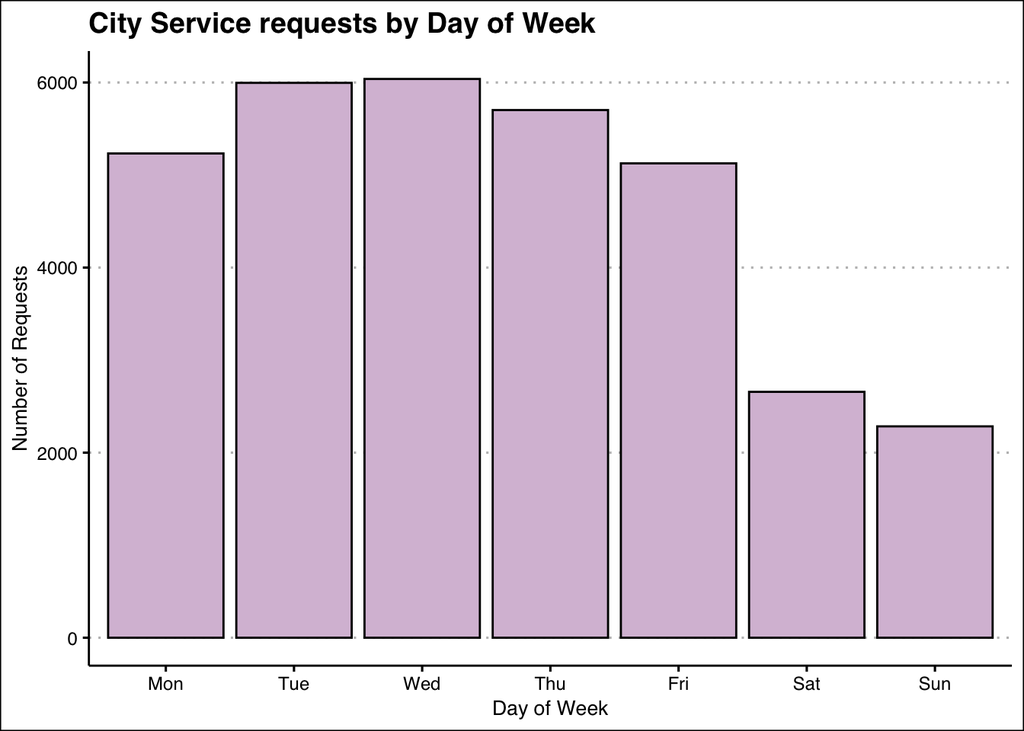

```r
data1 <- sunset_df %>%
  group_by(DayOfWeek = wday(Service.request.open.date, label = TRUE)) %>%
  summarise(Count = n()) %>%
  mutate(DayOfWeek = factor(DayOfWeek, levels = c("Mon", "Tue", "Wed", "Thu", "Fri", "Sat", "Sun"), ordered = TRUE)) %>%
  arrange(DayOfWeek)

library(ggplot2)
library(ggthemes)

ggplot(data1, aes(x=DayOfWeek, y=Count)) +
  geom_bar(stat = "identity", fill="thistle", color="black") +
  labs(title = "City Service requests by Day of Week",
       x = "Day of Week",
       y = "Number of Requests") +
  theme_clean()
```

The bar chart displays how many requests were made each day of week.Weekends have only about half the volume of requests, and the middle of the week is when the highest number of requests are occur. Maybe in the weekdays people tend to have more time or prefer to report rather than on weekends.

```r
top7_req_types <- sunset_df %>% group_by(Service.request.type) %>% summarise(Count = n()) %>% arrange(desc(Count)) %>% slice_head(n=7)
top7_req_types$Service.request.type
```

```
## [1] "Missed Green Bin Pickup Case"
## [2] "Building and Development Inquiry Case"
## [3] "Missed Garbage Bin Pickup Case"
## [4] "Garbage Bin Request Case"
## [5] "City and Park Trees Maintenance Case"
## [6] "Green Bin Request Case"
## [7] "Abandoned Non-Recyclables-Small Case"
```

```r
sunset_df_top7 <- sunset_df %>% filter(Service.request.type %in% top7_req_types$Service.request.type)
nrow(sunset_df_top7)
```

```
## [1] 16088
```

Now there are only 16088 records with top 7 service request types.

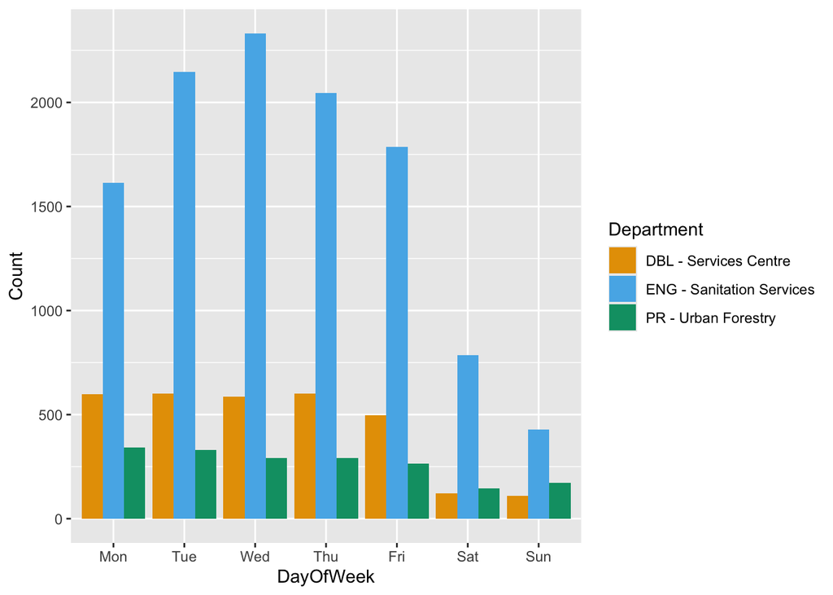

```r
data2 <- sunset_df_top7 %>% group_by(DayOfWeek = wday(Service.request.open.date, label = TRUE), Department) %>%
  summarise(Count = n(), .groups = "drop") %>%
  mutate(DayOfWeek = factor(DayOfWeek, levels = c("Mon", "Tue", "Wed", "Thu", "Fri", "Sat", "Sun"), ordered = TRUE)) %>%
  arrange(DayOfWeek)

ggplot(data2, aes(x=DayOfWeek, y=Count, fill = Department)) +
  geom_bar(stat = "identity", position = "dodge") +
  scale_fill_manual(values = c("#E69F00", "#56B4E9", "#009E73"))
```

```r
  labs(title = "City Service requests by Day of Week and Department",
       x = "Day of Week",
       y = "Number of Requests") +
  theme_foundation()
```

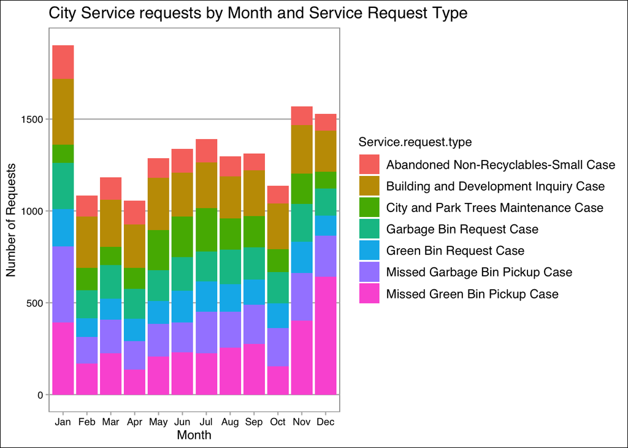

```r
data3 <- sunset_df_top7 %>% group_by(Month = month(Service.request.open.date, label = TRUE), Service.request.type) %>%
  summarise(Count = n(), .groups = "drop")

ggplot(data3, aes(x=Month, y=Count, fill = Service.request.type)) +
  geom_bar(stat = "identity") +
  labs(title = "City Service requests by Month and Service Request Type",
       x = "Month",
       y = "Number of Requests") +
  theme_calc()
```

January has highest number of requests, followed by November and December. Missed Green Bin Pickup Case occurred in these 3 months more than other months. In January post-holiday waste can put extra pressure to collection system. Also, November and December which are holiday season can lead to increase of waste too. November is often peak time for leaf fall, it can also impact collection system. It’s interesting that Building and Development inquires spike in January, and stays high during the year. January is like a month of new beginnings, when people tend to start new projects. Maybe it can be one of the reasons of large number of requests.

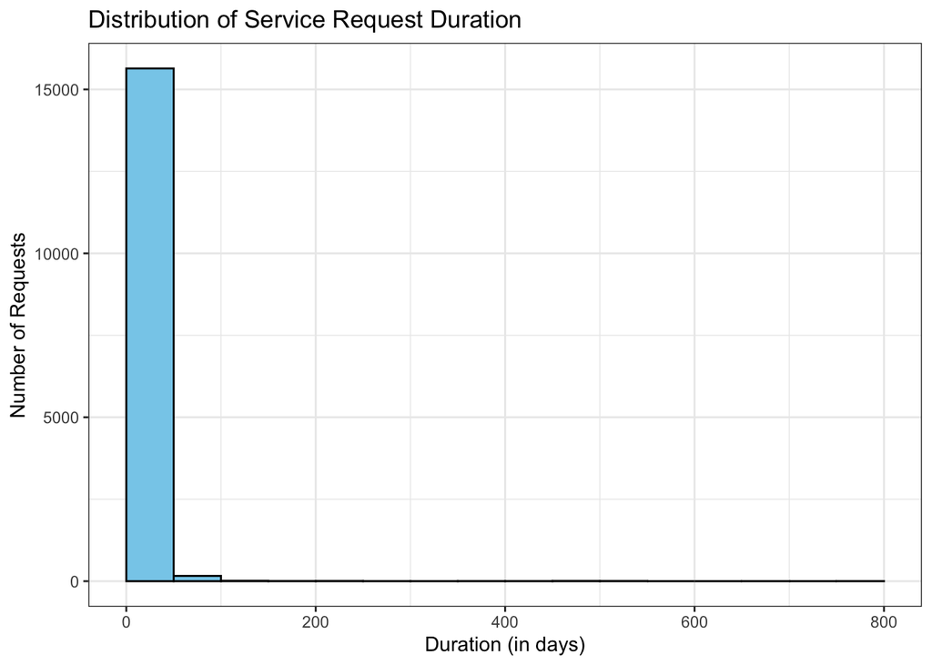

```r
ggplot(sunset_df_top7, aes(x=duration)) +
  geom_histogram(binwidth = 50, fill = "skyblue", color = "black", boundary = 0) +
  labs(title = "Distribution of Service Request Duration",
       x = "Duration (in days)",
       y = "Number of Requests"
       ) +
  theme_bw()
```

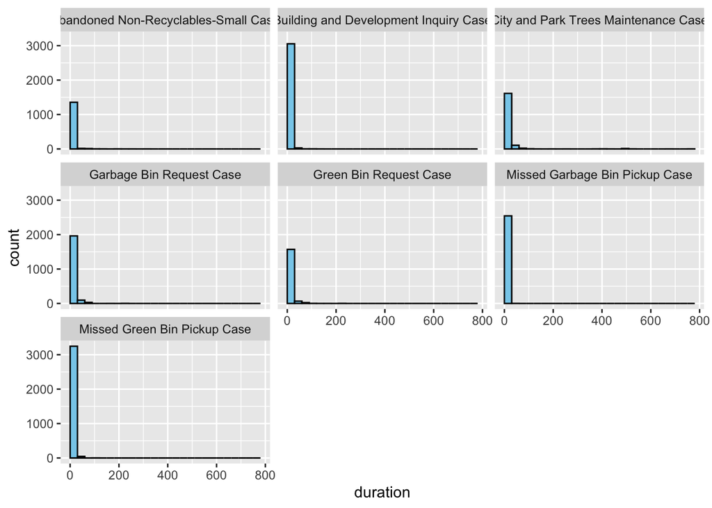

```r
ggplot(sunset_df_top7, aes(x=duration)) +
  geom_histogram(binwidth = 30, fill = "skyblue", color = "black", boundary = 0) +
  facet_wrap(~Service.request.type)
```

```r
  labs(title = "Distribution of Service Request Duration",
       x = "Duration (in days)",
       y = "Number of Requests"
       ) +
  theme_bw()
```

Most of the city requests have a same pattern, which can represent that city requests processes in a quick turnaround time. In some cases it can take longer than 30 days, maybe because of legal issues which can occur for the City and Trees Maintenance case (permits to make changes from multiple departments)

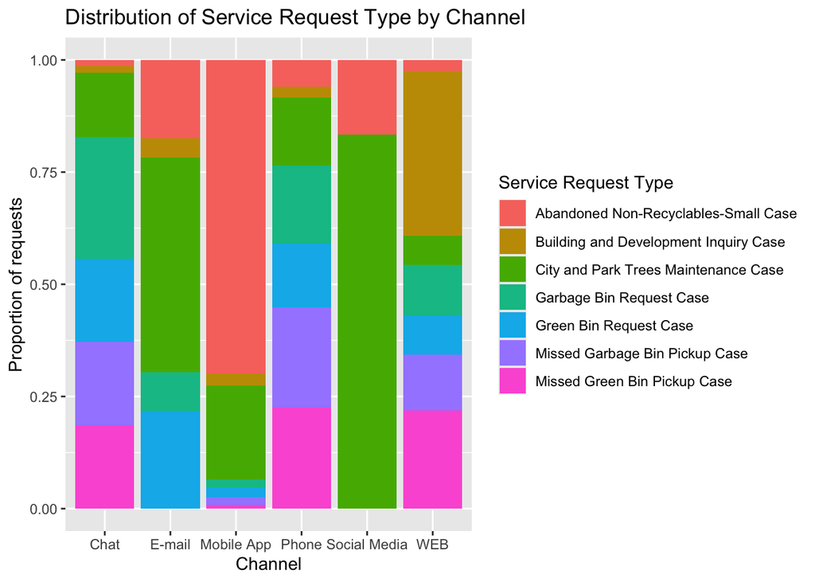

```r
ggplot(sunset_df_top7, aes(x=Channel, fill = Service.request.type)) +
  geom_bar(position = "fill") +
  labs(title = "Distribution of Service Request Type by Channel",
       y = "Proportion of requests",
       fill = "Service Request Type")
```

This plot shows the distribution of service request types across channels. Interesting, that Abandoned Non-Recyclables mostly reported via mobile app, while City and Park Maintenance dominate in Social Media and E-mail. Also, Building and Development Inquiry mostly reported via WEB. Different requests seems like have preferred channels. For instance, garbage and green bin requests prefer chat or phone, that do not require any additional resources like images. For the City and Park Maintenance social media is popular, maybe because people prefer post about their awareness of city to public discussion.

```r
library(leaflet)

sunset_df_map <- sunset_df %>% filter(!is.na(Latitude) & !is.na(Longitude))

leaflet(data = sunset_df_map) %>%
  addTiles() %>%
  addCircles(~Longitude, ~Latitude)
```

[interactive chart not shown]

```r
leaflet(data = sunset_df_map) %>%
  addProviderTiles("Esri.WorldImagery") %>%
  addCircles(~Longitude, ~Latitude, radius = 5, color = "gold", popup = ~Department)
```

[interactive chart not shown]

Created map with Esri World Imagery tiles, and added popup text which will display department name for each service request.